# CS100 Studio 3

Xiaohe Liu_Yiran Wang

October 5, 2016

Hypothesis 1: After we checked the plot created with jitter, there is a most strongest correlation when you have 4 friends and your happiness scale is 4. And we found that either too many friends or too little friens will cause less happiness. And generally, more firens will cause more happiness.

```r
friends_vs_happiness <- responses %>% select(Number.of.friends, Happiness.in.life) %>% arrange(desc(Number.of.friends))
head(friends_vs_happiness)
```

```
##   Number.of.friends Happiness.in.life
## 1                 5                 5
## 2                 5                 5
## 3                 5                 4
## 4                 5                 4
## 5                 5                 4
## 6                 5                 2
```

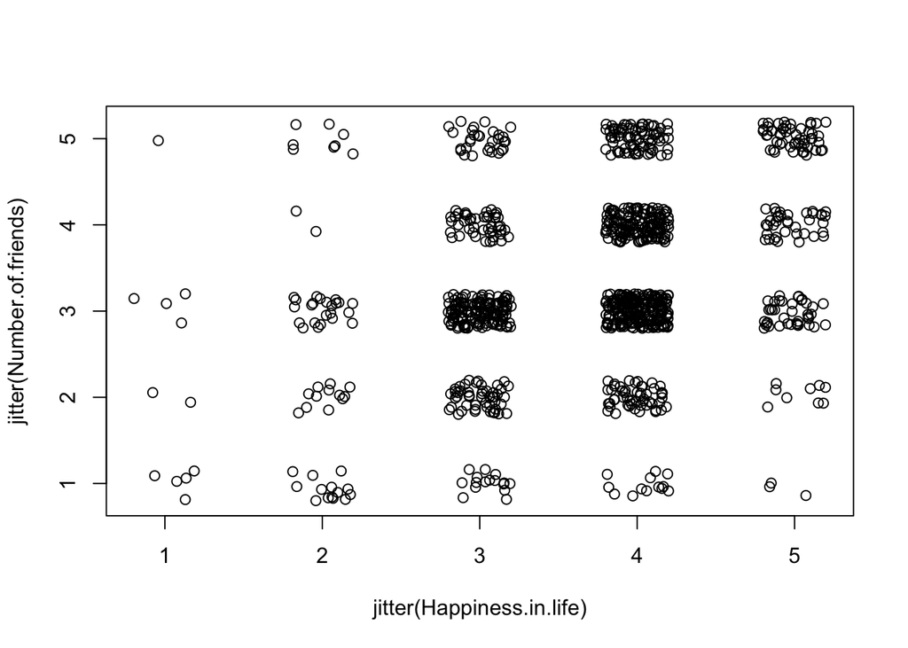

```r
plot(jitter(Number.of.friends) ~ jitter(Happiness.in.life), data=friends_vs_happiness)
```

Hypothesis 2:After created the plot by using the boxplot function, we can tell that there is no significant difference of the happiness between female and male.

```r
gender_vs_happiness <- responses %>% select(Gender, Happiness.in.life) %>% na.omit (Gender, Hapiness.in.life)
head(gender_vs_happiness)
```

```
##   Gender Happiness.in.life
## 1 female                 4
## 2 female                 4
## 3 female                 4
## 4 female                 2
## 5 female                 3
## 6   male                 3
```

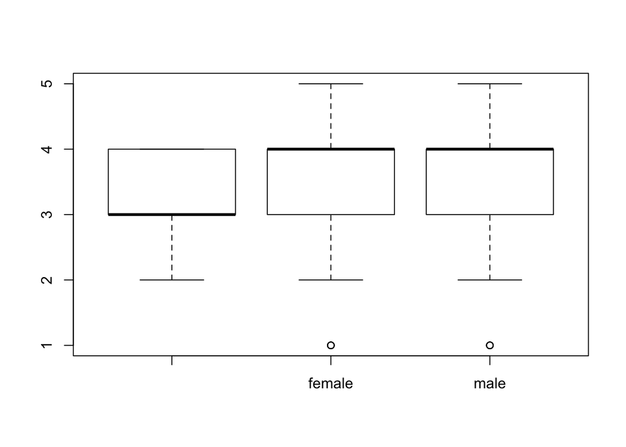

```r
boxplot(Happiness.in.life~Gender, data=gender_vs_happiness)
```

Hypothesis 3: According the plot that we created, we can tell there are outliers in this dataset. For instance, there is an outlier at the age about 28-29 with a extremely high happiness point. However, we can still tell from the plot that the age and the happiness has a postive correlation that people may have higher happiness points when their ages go up.

```r
happiness_vs_age <- responses %>% select (Age, Happiness.in.life)  %>% na.omit (Age, Happiness.in.life) %>% group_by(Age) %>% summarise(avg_happiness = mean (Happiness.in.life))
head(happiness_vs_age)
```

```
## # A tibble: 6 × 2
##     Age avg_happiness
##   <int>         <dbl>
## 1    15      3.600000
## 2    16      3.379310
## 3    17      3.566038
## 4    18      3.747967
## 5    19      3.765550
## 6    20      3.726804
```

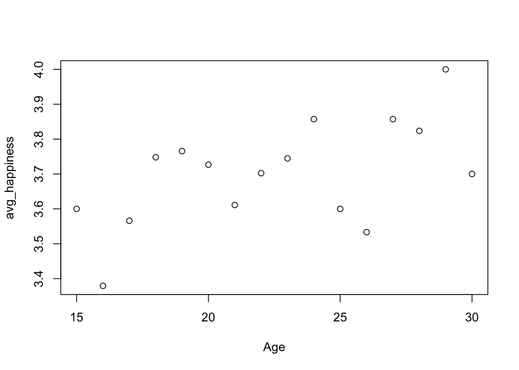

```r
plot(avg_happiness ~ Age, data=happiness_vs_age)
```

Hypothesis 4: After we checked the relationship between the comedy and the life hppiness, we can see tha there is positive correlation between the happiness and the comedy, with an outlier of comedy 1. We believe that is because people with higher happiness scale do not need to watch comedy.

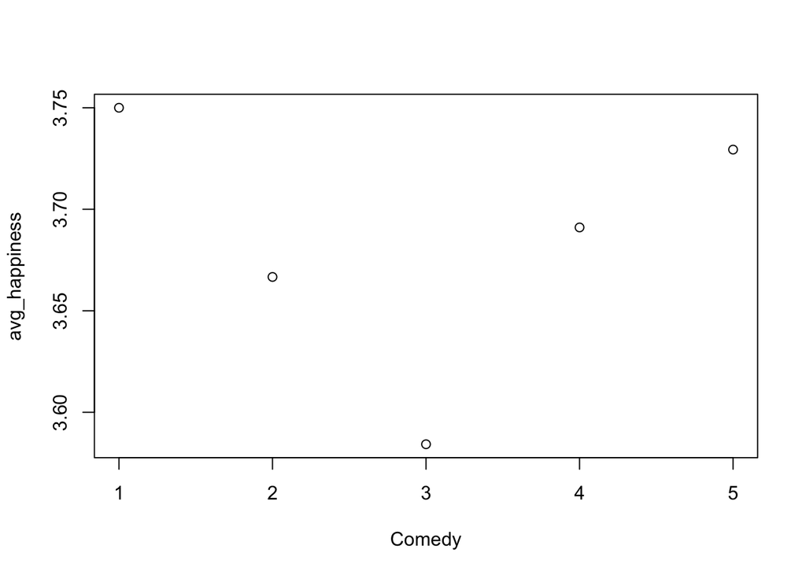

```r
happiness_vs_comedy <- responses %>% select (Comedy, Happiness.in.life) %>% na.omit (Comedy, Happiness.in.life) %>% group_by(Comedy) %>% summarise(avg_happiness = mean (Happiness.in.life))
plot(avg_happiness ~ Comedy, data=happiness_vs_comedy)
```

Hypothesis 5: after we have created the plot of the relationship between horror and life happiness, we saw a negative relationship between the horror and the life happiness, with a low scale in horror will cause a high scale in happiness.

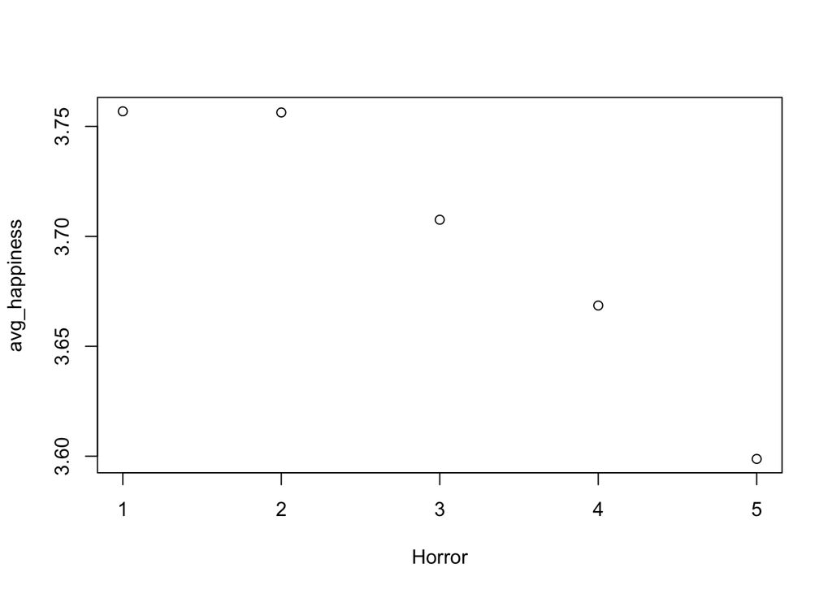

```r
happiness_vs_horror <- responses %>% select (Horror, Happiness.in.life) %>% na.omit (Horror, Happiness.in.life) %>% group_by(Horror) %>% summarise(avg_happiness = mean (Happiness.in.life))
plot(avg_happiness ~ Horror, data=happiness_vs_horror)
```

Hypothesis 6: We created the plot of the relationship between opera and the happiness. we didn’t see a clear correlation between these two variables. But there is a relatively positive relationshp between these two. Which is if you have watched a opear, you will more likely to get a higher happiness scale.

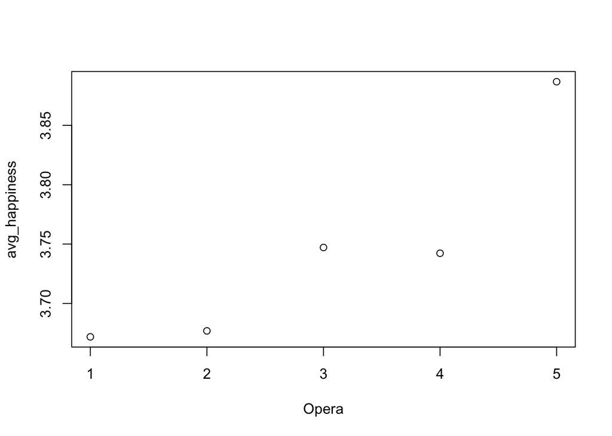

```r
happiness_vs_opera <- responses %>% select (Opera, Happiness.in.life) %>% na.omit (Opera, Happiness.in.life) %>% group_by(Opera) %>% summarise(avg_happiness = mean (Happiness.in.life))
plot(avg_happiness ~ Opera, data=happiness_vs_opera)
```